# Descriptives of bursts

## (set-up)

```python
import sys
import pandas as pd
import argparse
import numpy as np
import glob, os, re
import csv
from pathlib import Path
from datetime import datetime
import time
import collections
from multiprocessing import Pool, cpu_count
import matplotlib.pyplot as plt

import seaborn as sb
sb.set_theme(style="whitegrid")
```

## Load data

```python
data_dir = Path.cwd().parent
media = ['news','blogs','facebook','twitter','wikipedia']
burst_path = Path.cwd() / "2021-09-13_07-28-20"
master_burst = data_dir #/ "out_master_202109"

# abstracts
abstracts_df = pd.read_csv('{}/meta2019_withabstract_df_withkeywords.tsv'.format(data_dir.as_posix()),sep='\t',header=0)
alt_ids = abstracts_df.alt_id.values.tolist()

# load bursts data
all_bursts = pd.read_csv("{}/out_masterburstseq_202109/2021-09-22_15-57-19/all_bursts_df.tsv".format(data_dir.as_posix()),sep='\t',header=0)
all_bursts_ALT = pd.read_csv("{}/out_masterburstseq_202109/2021-09-22_15-57-19/all_bursts_ALT_df.tsv".format(data_dir.as_posix()),sep='\t',header=0)
```

### Number of bursts and the relevant posts/research papers

We have two kinds of bursts. The bursts calculated as described in Cheng et al, which have the following conditions:

- the daily number of posts is at least 10,
- no less than twice the average number of daily posts,
- a local maximum within a window of w = 7 days, and
- the number of posts per day between the two adjacent peaks should drop below the half of smaller peak’s height

And then an "alternative" burst calculation. TLDR; the number of posts is heavily skewed to Twitter. We note that some media/platforms are much more amenable to post creation (e.g. Twitter has a simple retweet but Wikipedia and news sites have strictier editing or publishing processes); therefore, we modify the first condition (at least 10 posts that day) per platform. We take the log of the number of posts overall (in the entire Altmetric dataset? Sohyeon needs to double check this), divide that by the log of the total number of posts, and then multiple this fraction by 10 (the original threshold). The resulting number is the minimum number of daily posts for each platform.

- Twitter - 9
- Facebook - 8
- News - 8
- Blogs - 7
- Wikipedia - 7

The difference between the bursts and alt bursts is not super substantial, however, alt bursts gives more comprehensive coverage of mentions while acknowledging differences in media/platforms.

```python
burst_count = all_bursts.groupby("alt_id").size().reset_index().rename(columns={0:"count"})
alt_burstcount = all_bursts_ALT.groupby("alt_id").size().reset_index().rename(columns={0:"count"})

print("{} alt_ids involved.".format(len(alt_ids)))

print("For {} bursts, there are {} relevant posts. This is for {} research papers (AKA, {} of 9675 papers have at least 1 burst).".format(len(all_bursts), all_bursts.burst_size.sum(),len(set(all_bursts.alt_id.values.tolist())), len(set(all_bursts.alt_id.values.tolist())) ))
print("For {} (alt) bursts, there are {} relevant posts. {} of 9675 papers have at least 1 (alt) burst.".format(len(all_bursts_ALT),all_bursts_ALT.burst_size.sum(),len(set(all_bursts_ALT.alt_id.values.tolist())) ))
print("{} research papers have at least 2 bursts. {} have at least 2 alt bursts.".format(len(burst_count.loc[burst_count['count'] >= 2]), len(alt_burstcount.loc[alt_burstcount['count'] >= 2])))
```

```
9675 alt_ids involved.
For 32666 bursts, there are 1702718 relevant posts. This is for 9616 research papers (AKA, 9616 of 9675 papers have at least 1 burst).
For 37001 (alt) bursts, there are 1739884 relevant posts. 9616 of 9675 papers have at least 1 (alt) burst.
7813 research papers have at least 2 bursts. 8192 have at least 2 alt bursts.
```

*The following figures are for posts with at least one burst!*

### Distribution of burst counts (number of bursts per research paper)

```
This shows how many bursts (left) and alt bursts (right) that research papers have:
```

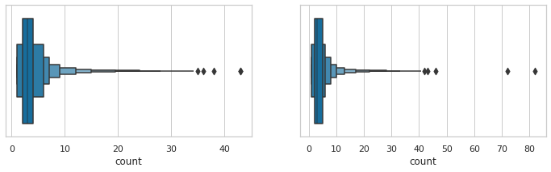

```python
fig, (ax1, ax2) = plt.subplots(1, 2)
fig.set_size_inches(12,3)
sb.boxenplot(data=burst_count,x="count",ax=ax1,palette="colorblind")
sb.boxenplot(data=alt_burstcount,x="count",ax=ax2,palette="colorblind")
print("This shows how many bursts (left) and alt bursts (right) that research papers have:")
```

```
This shows the histogram of how many research papers have x number of bursts (x-axis):
```

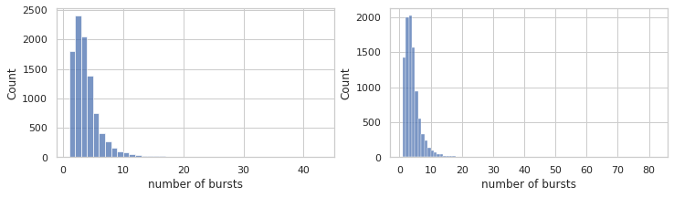

```python
fig, (ax1, ax2) = plt.subplots(1, 2)
fig.set_size_inches(12,3)
sb.histplot(data=burst_count.rename(columns={"count":"number of bursts"}),x="number of bursts",ax=ax1,binwidth=1)
sb.histplot(data=alt_burstcount.rename(columns={"count":"number of bursts"}),x="number of bursts",ax=ax2,binwidth=1)
print("This shows the histogram of how many research papers have x number of bursts (x-axis):")
```

```python
print("The median number of bursts per research paper is {}; for alt bursts, {}. The mean number is {} and {} respectively.".format(
    burst_count['count'].median(),
    alt_burstcount['count'].median(),
    burst_count['count'].mean(),
    alt_burstcount['count'].mean()))
print("The range is of burst count is {} ")
```

[output not shown]

```
The burst size (# of posts in a burst) is skewed to the right.
```

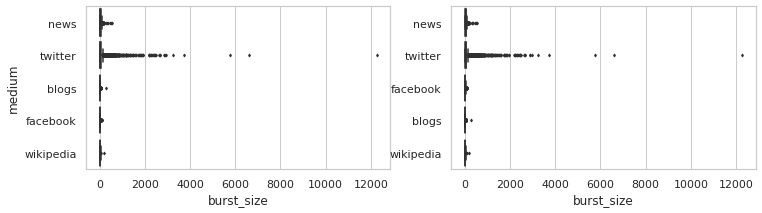

```python
# burst size (the number of posts in a burst) is (unsurprisingly) very skewed across bursts
fig, (ax1, ax2) = plt.subplots(1, 2)
fig.set_size_inches(12,3)
sb.boxplot(data=all_bursts,x="burst_size", y="medium",ax=ax1,palette="colorblind",fliersize=2)
sb.boxplot(data=all_bursts_ALT,x="burst_size", y="medium",ax=ax2,palette="colorblind",fliersize=2)
ax2.set_ylabel("")
print("The burst size (# of posts in a burst) is skewed to the right.")
```

### Platforms

```python
all_bursts.groupby("medium").size().reset_index().rename(columns={0:"num_bursts"}).merge(all_bursts_ALT.groupby("medium").size().reset_index().rename(columns={0:"num_alt_bursts"}),
    how='left',left_on="medium",right_on="medium")
```

|  | medium | num_bursts | num_alt_bursts |
| --- | --- | --- | --- |
| 0 | blogs | 1196 | 2264 |
| 1 | facebook | 741 | 1161 |
| 2 | news | 3572 | 4170 |
| 3 | twitter | 27141 | 29380 |
| 4 | wikipedia | 16 | 26 |

```python
# platform to platform sequences
p2p = all_bursts.groupby(["medium","next_burst_on"]).size().reset_index().rename(columns={0:"num_bursts"}).pivot("medium", "next_burst_on", "num_bursts").fillna(0)
p2p_alt = all_bursts_ALT.groupby(["medium","next_burst_on"]).size().reset_index().rename(columns={0:"num_bursts"}).pivot("medium", "next_burst_on", "num_bursts").fillna(0)
```

```python
p2p
```

| next_burst_on medium | blogs | facebook | news | twitter | wikipedia |
| --- | --- | --- | --- | --- | --- |
| blogs | 12.0 | 45.0 | 380.0 | 604.0 | 2.0 |
| facebook | 45.0 | 38.0 | 72.0 | 506.0 | 0.0 |
| news | 462.0 | 87.0 | 366.0 | 2001.0 | 1.0 |
| twitter | 315.0 | 386.0 | 1305.0 | 16404.0 | 6.0 |
| wikipedia | 0.0 | 0.0 | 1.0 | 7.0 | 5.0 |

```python
p2p_alt
```

| next_burst_on medium | blogs | facebook | news | twitter | wikipedia |
| --- | --- | --- | --- | --- | --- |
| blogs | 44 | 127 | 711 | 1162 | 2 |
| facebook | 96 | 63 | 103 | 773 | 1 |
| news | 789 | 141 | 389 | 2149 | 2 |
| twitter | 620 | 576 | 1504 | 18100 | 12 |
| wikipedia | 1 | 1 | 3 | 10 | 6 |

Tried to make a heatmap of the platform-to-platform sequences (first one is for regular bursts, second one is for alt bursts), but because twitter-to-twitter is such a large outlier, the map is kind of ugly. I am sure there are some workarounds for this, though.

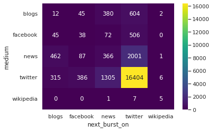

```python
ax = sb.heatmap(p2p, annot=True, cmap="viridis",fmt=".0f")
```

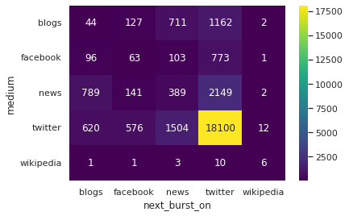

```python
ax = sb.heatmap(p2p_alt, annot=True,cmap="viridis",fmt=".0f")
```